# Tutorial 3: Naive and Cross-fitted DML

Madina Kurmangaliyeva

THIS TUTORIAL IS BASED ON THE FOLLOWING [BLOG POST](https://www.r-bloggers.com/cross-fitting-double-machine-learning-estimator/)

```r
packages <- c(
  "randomForest",
  "hdm",
  "glmnet",
  "tidyverse",
  "broom"
)

pacman::p_load(packages, character.only = TRUE)
```

# Single simulation

Let’s create data according to the following highly non-linear formula:

- Outcome: $y = \theta d + cos^2 ( z'b) + u$
- Assignment to treatment: $d = sin(z'b) + cos(z'b) + u$

We generate 500 observations and 10 nuisance variables:

```r
set.seed(1234)
N <- 500
p <- 10
theta <- 2
b <- 1/(1:p)
z <- matrix(rnorm(N*p), N, p) # = Generate z = #
g <- as.vector(cos(z%*%b)^2) # = Generate the function g = #
m <- as.vector(sin(z%*%b) + cos(z%*%b)) # = Generate the function m = #
d <- m + rnorm(N) # = Generate d = #
y <- theta*d + g + rnorm(N) # = Generate y = #
```

## Naive DML

### Step 1. Predict y

Fit random forest to predict `y` from `z` and collect predictions for the same sample. Note that we will be formally studying random forest next week. For now, we use as a black box (that works).

```r
model <- randomForest(z,y,maxnodes = 20)
G <- predict(model,z)
```

### Step 2. Predict d

Repeat the steps above but now for `d` and collect the prediction errors for `d`

```r
modeld <- randomForest(z, d, maxnodes = 20)
M <- predict(modeld, z)
V <- d - M
```

### Step 3. Calculate theta

Finally, we can calculate theta according to formula given on the slides. The formula should remind as of an IV estimate.

```r
theta_nv <- mean(V*(y - G))/mean(V*d)
theta_nv
```

```
## [1] 1.616767
```

Hmmm, it is quite far from the true value of theta. This is probably due to overfitting bias, that is why we need to do cross-fitting, as discussed in lecture slides.

## Cross-fitting DML

### Step 0. Split sample

In order to avoid overfitting bias, we need to split our data into K parts. Here we split in two:

```r
I  <- sort(sample(1:N,N/2))
IC <- setdiff(1:N,I)
```

### Step 1. Models for y

Fit y model in one sample, predict for another sample. Repeat again by switching the samples.

```r
model1 <- randomForest(z[IC,],y[IC],maxnodes = 10)
model2 <- randomForest(z[I,],y[I], maxnodes = 10)
G1 <- predict(model1,z[I,])
G2 <- predict(model2,z[IC,])
```

### Step 2. Models for d

Do the same for predicting `d`

```r
modeld1 <- randomForest(z[IC,],d[IC],maxnodes = 10)
modeld2 <- randomForest(z[I,],d[I],maxnodes = 10)
M1 <- predict(modeld1,z[I,])
M2 <- predict(modeld2,z[IC,])
V1 <- d[I] - M1
V2 <- d[IC] - M2
```

### Step 3. Compute Cross-Fitting DML theta

```r
theta1 <- mean(V1*(y[I] - G1))/mean(V1*d[I])
theta2 <- mean(V2*(y[IC] - G2))/mean(V2*d[IC])
theta_cf <- mean(c(theta1,theta2))
theta_cf
```

```
## [1] 1.901744
```

Much better! The estimate is closer to 2.

## Cross-fitting DML using cross-validated Lasso

### Step 0. Create interaction terms

Since we are using Lasso, we need to create interaction terms to capture possible non-linearities. As you can see, the polynomial of fifth degree has resulted in number of parameters larger than the number of observations. But this is not a problem for our lasso.

```r
X <- z %>%  as.data.frame()
X <- model.matrix(~.^5-1, data = X)
dim(X)
```

```
## [1] 500 637
```

### Step 1. Get predictions for `y`

**Exercise** Before we proceed, let’s see which variables does cross-validation choose for y (out of curiosity). Use the function from the previous tutorial `get_cvLassoCoefs.R`

```r
# Write your code here
# source("?")
# coefs_lasso_y <- ?
# print(coefs_lasso_y)
```

| coef | coef_names |
| --- | --- |
| 1.4730971230 | (Intercept) |
| 0.5800883454 | V1 |
| 0.3106870080 | V2 |
| 0.1569020879 | V3 |
| 0.1306568859 | V4 |
| 0.2460485337 | V5 |
| -0.3269804343 | V1:V2 |
| -0.1508157759 | V1:V3 |
| -0.1092235243 | V2:V3 |
| -0.0595755117 | V2:V7 |

[output cut: 37 more lines]

As you can see, we can approximate the complex function with just few interaction terms!

We transform our function `get_cvLassoCoefs.R` into a function that directly returns to us the predictions for a new sample at best lambda.

```r
source("./functions/get_cvLassoPredict.R")
G1l <- get_cvLassoPredict(X[IC,], y[IC], newX = X[I,])
G2l <- get_cvLassoPredict(X[I,], y[I], newX = X[IC,])
```

### Step 2. Get predictions for `d`

**Exercise** Finally, apply the same function to get predictions for `d`.

```r
# Write your answer here
# M1l <-
# M2l <-
# V1l <-
# V2l <-
```

### Step 3. Cross-fitting DML using cross-validated Lasso

```r
theta1l <- mean(V1l*(y[I] - G1l))/mean(V1l*d[I])
theta2l <- mean(V2l*(y[IC] - G2l))/mean(V2l*d[IC])
theta_cf_l <- mean(c(theta1l,theta2l))
theta_cf_l
```

```
## [1] 2.157523
```

Not exactly 2, but also good.

## Simulations

Let’s simulate 20 times and plot the distribution. It takes computational time, so I saved the results for 20 simulations. But you can always uncomment the two lines to do your own simulations.

```r
set.seed(555)
source("./functions/simulate_dml.R")
# results <- simulate_dml(theta = 2, N = 500, p = 10, nSim = 20)
# write_rds(results, "results/dml_simulations.rds")
results <-   read_rds("results/dml_simulations.rds")
```

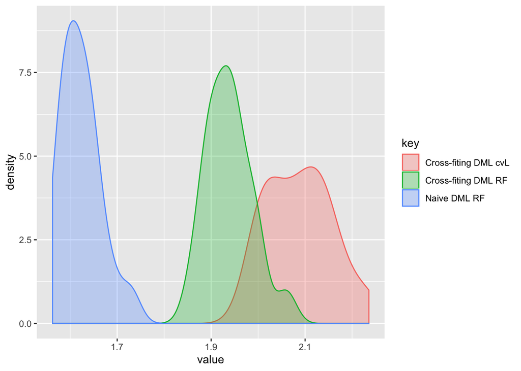

```r
results %>%
  as.data.frame() %>%
  gather() %>%
  ggplot(aes(x = value, color = key, fill = key)) +
  geom_density(alpha = 0.3)
```

# HOMEWORK: try neural networks for DML in python

1. Convert the content of `simulate_dml` to Python code, including Random forest and cross-validated Lasso, keeping the data generating process intact
2. Add a third method – neural network – and see how it compares to the cross-fitting DML cvL and RF. Send the plot of distributions to my email m.kurmangaliyeva@uvt.nl